# Time to Restore - 2025 data

Author

Erin Zylstra

Published

August 11, 2025

### Identifying priority species

Used list of priority species based on: TimeToRestore_AllPrioritySpecies_2024 [google sheet](https://docs.google.com/spreadsheets/d/1NnuTGT7OZuA9WGD0cg29d3INNV0n_x9C/edit?gid=794771851#gid=794771851) (extracted on 2 April 2025) and made the following changes:

- Corrected the spelling of one genus (*Vernonia*) and one species (*cespitosa*)
- Updated scientific and common names based on ITIS for mistflower (*Conoclinium*), basket-flower (*Centaurea*), and *Lantana*; will use the common name listed in ITIS/NPN data base for these species imoving forward.
- Using the common name listed in NPN database for *Sambucus nigra* and *Passiflora incarnata*, which were each listed twice in the googlesheet under two different common names.

```r
# Load list of priority species
spp_list <- read.csv("data/ttr-priorityspecies-20250402.csv",
                     na.strings = c(NA, ""))
spp_list <- spp_list %>%
  mutate(across(c(common_name, scientific_name), str_trim)) %>%
  # Edit spelling of one genus (Vernonia) and one species (cespitosa)
  # Update species based on ITIS for mistflower (Conoclinium),
  # basket-flower (Centaurea), and Lantana
  mutate(scientific_name = case_when(
    scientific_name == "Oenothera caespitosa" ~ "Oenothera cespitosa",
    scientific_name == "Veronia gigantea" ~ "Vernonia gigantea",
    scientific_name == "Conoclinium greggii" ~ "Conoclinium dissectum",
    scientific_name == "Centaurea americana" ~ "Plectocephalus americanus",
    scientific_name == "Lantana urticoides" ~ "Lantana horrida",
    .default = scientific_name
  )) %>%
  rename(ttr_common_name = common_name)

# Load information about NN species
nn_spp <- npn_species() %>% data.frame()
nn_spp <- nn_spp %>%
  filter(kingdom == "Plantae") %>%
  select(species_id, common_name, genus, species, functional_type) %>%
  mutate(scientific_name = paste(genus, species))

# Find NN info based on scientific name of priority species (inconsistent
# capitalization in priority list and a duplicate in NN database [Canada goldenrod])
spp_list <- spp_list %>%
  left_join(nn_spp, by = "scientific_name")
# Check that all priority species have a match in NN database
  # filter(spp_list, is.na(species_id))
# Are there any duplicates? Yes
  # count(spp_list, species_id) %>% filter(n > 1)
  # filter(spp_list, species_id == 90)
  # In priority list, Sambucus nigra listed as both black and common elderberry
  # filter(spp_list, species_id == 182)
  # In priority list, Passiflora incarnata listed as both purple passionflower and Maypop

# Remove entries for TTR priority species whose common name doesn't match NPN
spp_list <- spp_list %>%
  filter(!ttr_common_name %in% c("Maypop", "Common elderberry"))
```

This left us with 53 priority species.

### Downloading status-intensity data

Used rnpn package to download status and intensity data for priority species in Louisiana, New Mexico, Oklahoma, and Texas from 1 October 2023 through the present day. Downloaded observations of 4 phenophases: flowers or flower buds (flower), open flowers, fruits, and ripe fruits. Since leaves on milkweed plants may be important for monarch eggs and catepillars, we also downloaded observations of the leaves phenophase for the 8 species of milkweed on the priority list. After downloading the data, we appended information about intensity categories.

```r
# First, check that all species have these 4 phenophases
phenophases_byspp <- npn_phenophases_by_species(
  species_ids = c(spp_list$species_id),
  date = "2025-01-01"
) %>% data.frame()
phenophases_byspp %>%
  group_by(species_id, species_name) %>%
  summarize(p500 = ifelse(500 %in% phenophase_id, 1, 0),
            p501 = ifelse(501 %in% phenophase_id, 1, 0),
            p516 = ifelse(516 %in% phenophase_id, 1, 0),
            p390 = ifelse(390 %in% phenophase_id, 1, 0),
            .groups = "keep") %>%
  rowwise() %>%
  filter(sum(c_across(p500:p390)) < 4)
# All species use these 4 phenophases

# What phenophases do the milkweeds use?
milkweed_phps <- phenophases_byspp %>%
  filter(str_detect(species_name, "milkweed")) %>%
  select(species_id, species_name, pheno_class_id, phenophase_id, phenophase_name) %>%
  arrange(species_name, pheno_class_id, phenophase_id)
# Since leaves may be important for monarch eggs and catepillars, we may also
# want to include:
# 488 = Leaves (for milkweeds only)

# Download and format (or load existing) NPN data for priority plant species --#

# Observations in 4 states (LA, NM, OK, TX)
# Focus on 2025 data, but also download 2024 data (for fruits and/or comparison)

phenophases <- c(500, 501, 516, 390)
states4 <- c("LA", "NM", "OK", "TX")
  # Minor note: we could be missing observations in the four states if we use
  # the states argument in the download function because sometimes the state
  # field is missing or incorrect. Won't worry about that here, but would be
  # better in the long run to check state values based on lat/lons

data_filename <- "data/ttr-data-20242025.csv"

if (!file.exists(data_filename) | update_data == TRUE) {

  # Download flowering, fruiting data for 2024-2025 (including 2023 so that
  # we can calculated individual phenometrics for 2024, if needed)
  status_dl <- npn_download_status_data(
    request_source = "erinz",
    years = 2023:2025,
    species_ids = spp_list$species_id,
    phenophase_ids= phenophases,
    states = states4,
    additional_fields = c("observedby_person_id",
                          "partner_group",
                          "site_name",
                          "species_functional_type"))
  status_dl <- data.frame(status_dl)

  # Download leafing data for milkweeds in 2024-2025
  milkweeds <- spp_list %>%
    filter(str_detect(common_name, "milkweed")) %>%
    pull(species_id)
  status_mwleaf_dl <- npn_download_status_data(
    request_source = "erinz",
    years = 2023:2025,
    species_ids = milkweeds,
    phenophase_ids= 488,
    states = states4,
    additional_fields = c("observedby_person_id",
                          "partner_group",
                          "site_name",
                          "species_functional_type"))
  status_mwleaf_dl <- data.frame(status_mwleaf_dl)

  # Combine everything and format
  status_df <- rbind(status_dl, status_mwleaf_dl) %>%
    mutate(obsdate = ymd(observation_date),
           yr = year(obsdate),
           php = case_when(
             phenophase_id == 500 ~ "flower",
             phenophase_id == 501 ~ "open flower",
             phenophase_id == 516 ~ "fruit",
             phenophase_id == 390 ~ "ripe fruit",
             phenophase_id == 488 ~ "leaves")) %>%
    filter(obsdate >= "2023-10-01") %>%
    select(-c(update_datetime, elevation_in_meters, genus, species, kingdom,
              phenophase_description, abundance_value, observation_date)) %>%
    rename(person_id = observedby_person_id,
           func_type = species_functional_type,
           lat = latitude,
           lon = longitude)

  # Write to file
  write.csv(status_df, data_filename, row.names = FALSE)
  # Remove objects
  rm(status_df, status_dl, status_mwleaf_dl)
}

status <- read.csv(data_filename) %>%
  mutate(obsdate = ymd(obsdate),
         wy = ifelse(obsdate >= "2024-10-01", 2025, 2024))
```

```r
# Download information about intensity categories
ic <- npn_abundance_categories() %>% data.frame()
ic <- ic %>%
  rename(intensity_category_id = category_id,
         intensity_value_id = value_id,
         intensity_name = category_name,
         intensity_value = value_name) %>%
  select(-c(category_description, value_description))

# Extract just those categories that appear in status data and format:
ic_subset <- ic %>%
  filter(intensity_category_id %in% unique(status$intensity_category_id)) %>%
  mutate(value1 = NA,
         value2 = NA,
         intensity_type = case_when(
           str_detect(intensity_value, "%") ~ "percent",
           str_detect(intensity_value, "[0-9]") ~ "number",
           .default = "qualitative"
         ))
val12 <- which(colnames(ic_subset) %in% c("value1", "value2"))
for (i in 1:nrow(ic_subset)) {
  if (str_detect(ic_subset$intensity_value[i], " to ")) {
    ic_subset[i, val12] <- str_split_fixed(ic_subset$intensity_value[i], " to ", 2)
    ic_subset[i, val12] <- as.numeric(str_remove(ic_subset[i, val12], ","))
  } else if (str_detect(ic_subset$intensity_value[i], "-")) {
    ic_subset[i, val12] <- str_split_fixed(ic_subset$intensity_value[i], "-", 2)
    ic_subset[i, val12[2]] <- str_remove(ic_subset[i, val12[2]], "%")
  } else if (str_detect(ic_subset$intensity_value[i], "% or more")) {
    ic_subset[i, val12] <- str_remove(ic_subset$intensity_value[i], "% or more")
  } else if (str_detect(ic_subset$intensity_value[i], "Less than ")) {
    ic_subset[i, val12[1]] <- 0
    ic_subset[i, val12[2]] <- str_remove(ic_subset$intensity_value[i], "Less than ")
    ic_subset[i, val12[2]] <- str_remove(ic_subset[i, val12[2]], "%")
  } else if (str_detect(ic_subset$intensity_value[i], "More than ")) {
    ic_subset[i, val12] <- str_remove(ic_subset$intensity_value[i], "More than ")
    ic_subset[i, val12[1]] <- as.numeric(str_remove(ic_subset[i, val12[1]], ",")) + 1
    ic_subset[i, val12[2]] <- as.numeric(str_remove(ic_subset[i, val12[2]], ",")) + 1
  }
}
ic_subset <- ic_subset %>%
  mutate_at(c("value1", "value2"), as.numeric)

# Assigning a middle-ish value for each range (keeping it to nice numbers like
# 5, 50, 500, and 5000)
ic_subset <- ic_subset %>%
  mutate(mag = nchar(value1) - 1) %>%
  mutate(value = case_when(
    value1 == value2 ~ round(value1),
    intensity_type == "number" & value1 == 0 ~ 1,
    intensity_type == "number" & value1 != 0 ~
      round_any(rowMeans(across(value1:value2)), 5 * (10 ^ mag)),
    intensity_type == "percent" ~ round(rowMeans(across(value1:value2))),
    .default = NA
  )) %>%
  select(-c(mag, value1, value2))

ic_append <- ic_subset %>%
  select(intensity_category_id, intensity_name, intensity_value, value) %>%
  rename(intensity_cat = intensity_value,
         intensity = value)

status <- status %>%
  left_join(ic_append,
            by = c("intensity_category_id",
                   "intensity_value" = "intensity_cat")) %>%
  select(-intensity_category_id)
```

### Identifying issues related to reported intensity values

There was 1 instance since October 2024 where an observer did not report “yes” for a particular phenohpase, but did report an intensity value.

Table 1: Observations with an intensity value, where phenophase state was not positive.

| Site name | State | Species | Observation date | Phenophase | Status | Intensity |
| --- | --- | --- | --- | --- | --- | --- |
| Bayton Loop Preserve | TX | American beautyberry | 2024-12-21 | ripe fruit | -1 | Less than 5% |

To explore whether observers were counting the number of flowers rather than the number of inflorescences, we identified observations where the reported intensity value was in the highest two categories available for that species.

Table 2: Observations of flowers with high reported intensity values by water year.

| Species | Phenophase | Intensity category | No. 2024 observations | No. 2024 plants | No. 2025 observations | No. 2025 plants |
| --- | --- | --- | --- | --- | --- | --- |
| American beautyberry | flower | 1,001 to 10,000 | 4 | 4 | 0 | 0 |
| Texas lupine | flower | 101 to 1,000 | 0 | 0 | 1 | 1 |
| button eryngo | flower | 101 to 1,000 | 4 | 1 | 0 | 0 |
| cardinalflower | flower | 101 to 1,000 | 1 | 1 | 0 | 0 |
| common buttonbush | flower | 1,001 to 10,000 | 15 | 6 | 0 | 0 |
| eastern baccharis | flower | 1,001 to 10,000 | 6 | 3 | 1 | 1 |
| eastern baccharis | flower | More than 10,000 | 0 | 0 | 1 | 1 |
| eastern redbud | flower | 1,001 to 10,000 | 4 | 3 | 14 | 4 |
| horsetail milkweed | flower | 101 to 1,000 | 3 | 1 | 0 | 0 |
| purple passionflower | flower | 101 to 1,000 | 2 | 1 | 0 | 0 |
| red maple | flower | 1,001 to 10,000 | 75 | 13 | 88 | 14 |
| red maple | flower | More than 10,000 | 6 | 1 | 2 | 1 |
| rubber rabbitbrush | flower | 1,001 to 10,000 | 12 | 3 | 2 | 2 |
| rubber rabbitbrush | flower | More than 10,000 | 8 | 4 | 0 | 0 |
| seaside goldenrod | flower | 101 to 1,000 | 0 | 0 | 2 | 1 |
| white crownbeard | flower | 101 to 1,000 | 0 | 0 | 2 | 1 |
| wild bergamot | flower | 101 to 1,000 | 1 | 1 | 0 | 0 |

### Identifying inconsistent phenophase status reports

We wanted to identify when observers provided incompatible status reports for different phenophases. In particular, we identified when observers reported a “no” to flowers but reported a “yes” or “?” to open flowers. Similarly, we identified when observers reported a “no” to fruits but reported a “yes” or “?” to ripe fruits. We also identified when observers reported a “?” to flowers but reported a “yes” to open flowers, and when observers reported a “?” to fruits but reported a “yes” to ripe fruits.

```r
# To look at this, can't have more than one observation of a plant per person
# per day. We've already removed duplicates, but now need to resolve instances
# where somebody made multiple observations of the same plant on the same date
# that differed in some way.

  # For now, will keep record with more advanced phenophase or higher
  # intensity value. Will do this by sorting observations in descending
  # order and keeping only the first
  inddateobsp <- status %>%
    group_by(common_name, individual_id, obsdate, person_id, php) %>%
    summarize(n_obs = n(),
              .groups = "keep") %>%
    data.frame()
  inddateobsp$obsnum <- 1:nrow(inddateobsp)

  status <- status %>%
    arrange(person_id, individual_id, obsdate, php,
            desc(phenophase_status), desc(intensity)) %>%
    left_join(select(inddateobsp, -c(n_obs, common_name)),
              by = c("person_id", "individual_id",
                     "obsdate", "php")) %>%
    # Create "dups" column, where dups > 1 indicates that the observation can be
    # removed since there's another observation that same day with more advanced
    # phenology or higher intensity/abundance.
    mutate(dups = sequence(rle(as.character(obsnum))$lengths))

  # Remove extra observations and unnecessary columns
  status <- status %>%
    filter(dups == 1) %>%
    select(-c(obsnum, dups)) %>%
    arrange(common_name, obsdate, person_id, php)

# To identify inconsistent status values, will need to put flower/fruit data
# into wide form (all data for a plant visit in the same row). Removing
# unknown status observations first (<0.5% of fruit/flower observations).
statusw <- status %>%
  filter(php != "leaves") %>%
  filter(phenophase_status != -1) %>%
  select(person_id, partner_group, site_id, state, common_name, individual_id,
         wy, obsdate, php, phenophase_status, intensity) %>%
  rename(status = phenophase_status) %>%
  pivot_wider(names_from = php,
              names_glue = "{php}_{.value}",
              values_from = c(status, intensity)) %>%
  data.frame()

# Identify phenophase status inconsistencies
# NOTE: changing NAs to 999 in order to make this code simpler
statusw <- statusw %>%
  mutate(across(contains("status"), ~replace_na(., 999))) %>%
  # Problem: flower = 0, open = NA or 1
  mutate(flower0_openNot0 = ifelse(flower_status == 0 & open.flower_status != 0,
                                   1, 0)) %>%
  # Problem: flower = NA, open = 1
  mutate(flowerNA_open1 = ifelse(flower_status == 999 & open.flower_status == 1,
                                 1, 0)) %>%
  # Problem: fruit = 0, ripe = NA or 1
  mutate(fruit0_ripeNot0 = ifelse(fruit_status == 0 & ripe.fruit_status != 0,
                                   1, 0)) %>%
  # Problem: fruit = NA, ripe = 1
  mutate(fruitNA_ripe1 = ifelse(fruit_status == 999 & ripe.fruit_status == 1,
                                1, 0))

# Table summarizing problems with flower/open flower status
flower_probs <- statusw %>%
  group_by(common_name, wy) %>%
  summarize(n = n(),
            n_flower0 = sum(flower_status == 0),
            n_flower1 = sum(flower_status == 1),
            n_flowerNA = sum(flower_status == 999),
            n_open0 = sum(open.flower_status == 0),
            n_open1 = sum(open.flower_status == 1),
            n_openNA = sum(open.flower_status == 999),
            n_flower0_openNot0 = sum(flower0_openNot0 == 1),
            n_flowerNA_open1 = sum(flowerNA_open1 == 1),
            .groups = "keep") %>%
  filter(n_flower0_openNot0 + n_flowerNA_open1 > 0) %>%
  data.frame()

# Table summarizing problems with fruit/ripe fruit status
fruit_probs <- statusw %>%
  group_by(common_name, wy) %>%
  summarize(n = n(),
            n_fruit0 = sum(fruit_status == 0),
            n_fruit1 = sum(fruit_status == 1),
            n_fruitNA = sum(fruit_status == 999),
            n_ripe0 = sum(ripe.fruit_status == 0),
            n_ripe1 = sum(ripe.fruit_status == 1),
            n_ripeNA = sum(ripe.fruit_status == 999),
            n_fruit0_ripeNot0 = sum(fruit0_ripeNot0 == 1),
            n_fruitNA_ripe1 = sum(fruitNA_ripe1 == 1),
            .groups = "keep") %>%
  filter(n_fruit0_ripeNot0 + n_fruitNA_ripe1 > 0) %>%
  data.frame()
```

Table 3: Inconsistent reports of flowering phenophase statuses by species and water year

| Species | Water year | No. observations | Flowers:no AND Open flowers:yes/? | Flowers:? AND Open flowers:yes |
| --- | --- | --- | --- | --- |
| American beautyberry | 2024 | 585 | 0 | 28 |
| American beautyberry | 2025 | 386 | 2 | 0 |
| common buttonbush | 2024 | 300 | 2 | 0 |
| common buttonbush | 2025 | 163 | 1 | 0 |
| common sunflower | 2024 | 156 | 1 | 0 |
| eastern baccharis | 2025 | 64 | 1 | 0 |
| eastern purple coneflower | 2024 | 34 | 1 | 0 |
| eastern redbud | 2024 | 462 | 4 | 2 |
| horsetail milkweed | 2024 | 147 | 1 | 0 |
| purple prairie clover | 2024 | 250 | 0 | 17 |
| red maple | 2024 | 497 | 1 | 0 |
| red maple | 2025 | 291 | 2 | 0 |
| rubber rabbitbrush | 2024 | 178 | 3 | 0 |
| wax mallow | 2025 | 27 | 1 | 0 |

Table 4: Inconsistent reports of fruiting phenophase statuses

| Species | Water year | No. observations | Fruit:no AND Ripe fruit:yes/? | Fruit:? AND Ripe fruit:yes |
| --- | --- | --- | --- | --- |
| American star-thistle | 2025 | 7 | 1 | 0 |
| blackeyed Susan | 2024 | 1 | 1 | 0 |
| blackeyed Susan | 2025 | 7 | 1 | 0 |
| common buttonbush | 2024 | 300 | 1 | 0 |
| common sunflower | 2024 | 156 | 4 | 0 |
| common sunflower | 2025 | 53 | 1 | 0 |
| eastern baccharis | 2024 | 114 | 1 | 0 |
| eastern redbud | 2024 | 462 | 1 | 0 |
| eastern redbud | 2025 | 206 | 2 | 0 |
| horsetail milkweed | 2024 | 147 | 1 | 0 |
| horsetail milkweed | 2025 | 40 | 1 | 0 |
| purple passionflower | 2025 | 12 | 1 | 0 |
| rubber rabbitbrush | 2025 | 59 | 1 | 0 |
| white crownbeard | 2025 | 75 | 1 | 0 |

### Summary of sites monitored

```r
# Plot locations where flowering/fruiting or milkweed leaves observed in current
# water year (Oct 2024 and present)
status <- status %>%
  mutate(ind_date = paste0(individual_id, "_", obsdate))

locs <- status %>%
  filter(wy == 2025) %>%
  group_by(site_id, site_name, lat, lon, state) %>%
  summarize(nspp = n_distinct(common_name),
            nplants = n_distinct(individual_id),
            nobservers = n_distinct(person_id),
            # nobs: Number of observations, where an observations is all
            # data (all phenophases) submitted for a plant on given date
            nobs = n_distinct(ind_date),
            .groups = "keep") %>%
  data.frame()

locs_by_state_int <- locs %>%
  group_by(state) %>%
  summarize(nspp_per_site = round(mean(nspp), 2),
            nplants_per_site = round(mean(nplants), 2),
            nobs_per_site = round(mean(nobs),2)) %>%
  data.frame()

locs_by_state <- status %>%
  filter(wy == 2025) %>%
  group_by(state) %>%
  summarize(nsites = n_distinct(site_id),
            nspp = n_distinct(common_name),
            nplants = n_distinct(individual_id),
            nobs = n_distinct(ind_date)) %>%
  data.frame() %>%
  left_join(locs_by_state_int, by = "state")

map <- leaflet(locs) %>%
  fitBounds(lng1 = -107, lat1 = 29, lng2 = -89, lat2 = 36) %>%
  addTiles() %>%
  addCircleMarkers(radius = ~(nspp+3), color = "blue", weight = 2, opacity = 0.7,
                   popup = paste(locs$site_name, "<br>",
                                 "No. species:", locs$nspp, "<br>",
                                 "No. plants:", locs$nplants, "<br>",
                                 "No. observers:", locs$nobservers))
```

Figure 1: Locations of sites in where priority species were monitored between October 2024 and present. Size of circles vary with the number of species monitored at that site. Clicking on a circle provides basic information about each site.

[interactive chart not shown]

Table 5: Summary of sites monitored in each state from October 2024 to present. Here, an observation is all data collected for a plant on a given date.

| State | No. sites | No. species | No. plants | No. observations | Mean no. species per site | Mean no. plants per site | Mean no. of observations per site |
| --- | --- | --- | --- | --- | --- | --- | --- |
| LA | 12 | 10 | 55 | 621 | 2.50 | 4.58 | 51.75 |
| NM | 5 | 6 | 14 | 183 | 2.00 | 2.80 | 36.60 |
| OK | 2 | 2 | 6 | 116 | 1.00 | 3.00 | 58.00 |
| TX | 63 | 29 | 159 | 858 | 2.24 | 2.52 | 13.62 |

### Summary of species monitored

Table 6: Summary of plants monitored from October 2024 to present. Here, an observation is all data collected for a plant on a given date.

| Species | Functional group | No. plants: LA | No. plants: NM | No. plants: OK | No. plants: TX | Total no. plants | No. sites | Mean no. observations |
| --- | --- | --- | --- | --- | --- | --- | --- | --- |
| American beautyberry | Deciduous broadleaf | 8 | 0 | 0 | 33 | 41 | 27 | 9.1 |
| red maple | Deciduous broadleaf | 22 | 0 | 0 | 2 | 24 | 9 | 11.9 |
| eastern redbud | Deciduous broadleaf | 2 | 1 | 1 | 18 | 22 | 20 | 9.0 |
| common buttonbush | Deciduous broadleaf | 10 | 0 | 0 | 7 | 17 | 13 | 8.0 |
| wax mallow | Deciduous broadleaf | 0 | 0 | 0 | 9 | 9 | 8 | 3.0 |
| eastern baccharis | Deciduous broadleaf | 6 | 0 | 0 | 0 | 6 | 4 | 10.7 |
| West Indian shrubverbena | Deciduous broadleaf | 0 | 0 | 0 | 4 | 4 | 4 | 1.8 |
| black elderberry | Deciduous broadleaf | 1 | 0 | 0 | 0 | 1 | 1 | 1.0 |
| trumpet honeysuckle | Deciduous broadleaf | 0 | 0 | 0 | 1 | 1 | 1 | 34.0 |
| rubber rabbitbrush | Drought deciduous broadleaf | 0 | 4 | 0 | 0 | 4 | 2 | 14.8 |
| Texas lupine | Forb | 0 | 0 | 0 | 14 | 14 | 13 | 4.4 |
| white crownbeard | Forb | 2 | 0 | 0 | 8 | 10 | 9 | 7.5 |
| blue mistflower | Forb | 0 | 0 | 0 | 8 | 8 | 8 | 2.1 |
| mealycup sage | Forb | 0 | 0 | 0 | 7 | 7 | 6 | 2.4 |
| wild bergamot | Forb | 1 | 0 | 0 | 5 | 6 | 6 | 4.0 |
| common sunflower | Forb | 0 | 2 | 0 | 3 | 5 | 5 | 10.6 |
| firewheel | Forb | 0 | 0 | 0 | 5 | 5 | 5 | 5.2 |
| purple prairie clover | Forb | 0 | 0 | 5 | 0 | 5 | 1 | 23.0 |
| purple passionflower | Forb | 1 | 0 | 0 | 3 | 4 | 4 | 3.0 |
| American star-thistle | Forb | 0 | 0 | 0 | 3 | 3 | 3 | 2.0 |
| blackeyed Susan | Forb | 0 | 0 | 0 | 3 | 3 | 3 | 2.3 |
| green antelopehorn | Forb | 0 | 0 | 0 | 3 | 3 | 3 | 5.0 |
| horsetail milkweed | Forb | 0 | 3 | 0 | 0 | 3 | 2 | 13.3 |
| spider milkweed | Forb | 0 | 0 | 0 | 3 | 3 | 2 | 2.7 |
| Canada goldenrod | Forb | 0 | 0 | 0 | 2 | 2 | 2 | 1.5 |
| aquatic milkweed | Forb | 0 | 0 | 0 | 2 | 2 | 2 | 6.5 |
| broadleaf milkweed | Forb | 0 | 2 | 0 | 0 | 2 | 1 | 10.0 |
| button eryngo | Forb | 2 | 0 | 0 | 0 | 2 | 1 | 8.0 |
| eastern purple coneflower | Forb | 0 | 0 | 0 | 2 | 2 | 2 | 2.0 |
| lemon beebalm | Forb | 0 | 0 | 0 | 2 | 2 | 2 | 1.0 |
| palmleaf thoroughwort | Forb | 0 | 0 | 0 | 2 | 2 | 2 | 3.0 |
| showy milkweed | Forb | 0 | 2 | 0 | 0 | 2 | 2 | 15.0 |
| golden crownbeard | Forb | 0 | 0 | 0 | 1 | 1 | 1 | 1.0 |
| upright prairie coneflower | Forb | 0 | 0 | 0 | 1 | 1 | 1 | 1.0 |
| turkey tangle fogfruit | Semi-evergreen forb | 0 | 0 | 0 | 6 | 6 | 6 | 2.2 |
| seaside goldenrod | Semi-evergreen forb | 0 | 0 | 0 | 1 | 1 | 1 | 6.0 |
| straggler daisy | Semi-evergreen forb | 0 | 0 | 0 | 1 | 1 | 1 | 1.0 |

### Summary of observers

Table 7: Summary of people who submitted data for priority species since October 2024, by state. Values in table are means, with range of values in parentheses.

| State | No. observers | No. species per observer | No. plants per observer | No. plants per species |
| --- | --- | --- | --- | --- |
| LA | 16 | 3.44 (1 - 6) | 8.12 (1 - 21) | 2.43 (1 - 7) |
| NM | 18 | 1.89 (1 - 5) | 2.44 (1 - 8) | 1.14 (1 - 1.6) |
| OK | 7 | 1 (1 - 1) | 4.43 (1 - 5) | 4.43 (1 - 5) |
| TX | 59 | 2.37 (1 - 16) | 3.22 (1 - 20) | 1.62 (1 - 5) |

Figure 2: Number of species each observer monitored since October 2024.

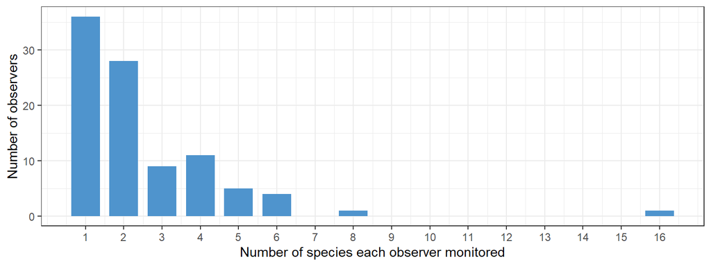

Figure 3: Number of plants per species that observers monitored since October 2024

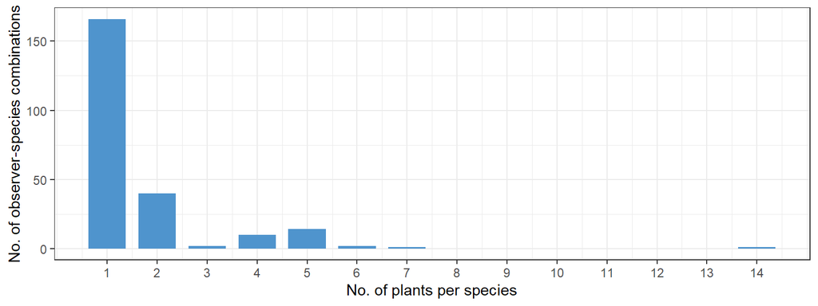

### Observation frequency: Reporting a “no” prior to the first “yes”

To evaluate observation frequency, we downloaded individual phenometrics data for priority species from 1 October 2023 through the present day.

```r
# Download individual phenometrics data
ip_filename <- "data/ttr-ipdata-20242025.csv"

if (!file.exists(ip_filename) | update_data == TRUE) {

  # Download flowering, fruiting data for Oct 2024 - April 2025 and Oct 2023 -
  # Sep 2024 (phenometrics aggregated over water year).
  # After some experimenting, it looks like when requesting data by water year,
  # the years argument corresponds to the start of each year in October. So we
  # need to use years = 2023:2024 for this call.
  ip_dl <- npn_download_individual_phenometrics(
    request_source = "erinz",
    years = 2023:2024,
    period_start = "10-01",
    period_end = "09-30",
    species_ids = spp_list$species_id,
    phenophase_ids= phenophases,
    states = states4,
    additional_fields = c("observedby_person_id",
                          "partner_group",
                          "site_name",
                          "species_functional_type"))
  ip_dl <- data.frame(ip_dl)

  # Download leafing data for milkweeds in 2024-2025
  milkweeds <- spp_list %>%
    filter(str_detect(common_name, "milkweed")) %>%
    pull(species_id)
  ip_mwleaf_dl <- npn_download_individual_phenometrics(
    request_source = "erinz",
    years = 2023:2024,
    period_start = "10-01",
    period_end = "09-30",
    species_ids = milkweeds,
    phenophase_ids= 488,
    states = states4,
    additional_fields = c("observedby_person_id",
                          "partner_group",
                          "site_name",
                          "species_functional_type"))
  ip_mwleaf_dl <- data.frame(ip_mwleaf_dl)

  # Combine everything and format
  ip_df <- rbind(ip_dl, ip_mwleaf_dl) %>%
    mutate(php = case_when(
      phenophase_id == 500 ~ "flower",
      phenophase_id == 501 ~ "open flower",
      phenophase_id == 516 ~ "fruit",
      phenophase_id == 390 ~ "ripe fruit",
      phenophase_id == 488 ~ "leaves")) %>%
    select(-c(observedby_person_id, elevation_in_meters, genus, species, kingdom,
              phenophase_description, first_yes_month, first_yes_day,
              first_yes_julian_date, last_yes_year, last_yes_month,
              last_yes_day, last_yes_julian_date, numdays_until_next_no)) %>%
    rename(func_type = species_functional_type,
           lat = latitude,
           lon = longitude,
           prior_no = numdays_since_prior_no)

  # Write to file
  write.csv(ip_df, ip_filename, row.names = FALSE)
  # Remove objects
  rm(ip_df, ip_dl, ip_mwleaf_dl)

}

ip <- read.csv(ip_filename)
```

For these summaries, we evaluated observation frequency by classifying flowering and fruiting observations based on the time elapsed between a “no” observation and the first “yes” observation of a given phenophase. Here, we compared first yeses that were submitted between 1 November 2024 and the present (~2025 water year) with first yeses that were submitted between 1 November 2023 and 30 September 2024 (~2024 water year).

```r
ip <- ip %>%
  # Create "season" (Nov 2024 - April 2025 = 2025)
  mutate(yes_date = parse_date_time(paste(first_yes_year, first_yes_doy),
                                    orders = "Y j"),
         yes_month = month(yes_date),
         season = case_when(
           yes_month %in% 11:12 ~ first_yes_year + 1,
           yes_month %in% 1:9 ~ first_yes_year,
           .default = NA))
# check
# count(ip, first_yes_year, yes_month, season)

# Proportion of first yeses that are preceded by a prior no within X days,
# by phenophase and season
obsfreq_php <- ip %>%
  filter(!is.na(season)) %>%
  filter(php != "leaves") %>%
  mutate(php = factor(php, levels = c("flower", "open flower", "fruit",
                                      "ripe fruit"))) %>%
  group_by(season, php) %>%
  summarize(nobs = n(),
            nobs3 = sum(!is.na(prior_no) & prior_no <= 3),
            nobs7 = sum(!is.na(prior_no) & prior_no <= 7),
            nobs14 = sum(!is.na(prior_no) & prior_no <= 14),
            nobs30 = sum(!is.na(prior_no) & prior_no <= 30),
            .groups = "keep") %>%
  mutate(prop3 = round(nobs3/nobs, 2),
         prop7 = round(nobs7/nobs, 2),
         prop14 = round(nobs14/nobs, 2),
         prop30 = round(nobs30/nobs, 2)) %>%
  data.frame()

# Make a bar chart for this (minus milkweed leaf observations because few of them)
obsfreq_phpl <- ip %>%
  filter(!is.na(season)) %>%
  filter(php != "leaves") %>%
  mutate(php = factor(php, levels = c("flower", "open flower",
                                      "fruit", "ripe fruit"))) %>%
  group_by(season, php) %>%
  summarize(nobs03 = sum(!is.na(prior_no) & prior_no %in% 1:3),
            nobs07 = sum(!is.na(prior_no) & prior_no %in% 4:7),
            nobs14 = sum(!is.na(prior_no) & prior_no %in% 8:14),
            nobs30 = sum(!is.na(prior_no) & prior_no %in% 15:30),
            nobs99 = sum((!is.na(prior_no) & prior_no > 30) | is.na(prior_no)),
            .groups = "keep") %>%
  pivot_longer(cols = nobs03:nobs99,
               names_to = "cat",
               values_to = "nobs") %>%
  data.frame()

freq_by_php <- ggplot(obsfreq_phpl) +
  geom_bar(aes(x = php, y = nobs, fill = cat),
           position = "stack",
           stat = "identity") +
  scale_fill_manual(values = c("#7fc97f", "#beaed4", "#fdc086",
                               "#ffff99", "#386cb0"),
                    labels = c("1-3 days", "4-7 days", "8-14 days",
                               "15-30 days", ">30 days")) +
  facet_grid( ~ season) +
  labs(x = "Phenophase", y = 'Number of first "yes" observations',
       fill = 'Prior "no"') +
  theme_bw()

# Proportion of first yeses that are preceded by a prior no within X days,
# by species and season
obsfreq_spp <- ip %>%
  filter(!is.na(season)) %>%
  filter(php != "leaves") %>%
  group_by(common_name, season) %>%
  summarize(nobs = n(),
            nobs3 = sum(!is.na(prior_no) & prior_no <= 3),
            nobs7 = sum(!is.na(prior_no) & prior_no <= 7),
            nobs14 = sum(!is.na(prior_no) & prior_no <= 14),
            nobs30 = sum(!is.na(prior_no) & prior_no <= 30),
            .groups = "keep") %>%
  mutate(prop3 = round(nobs3/nobs, 2),
         prop7 = round(nobs7/nobs, 2),
         prop14 = round(nobs14/nobs, 2),
         prop30 = round(nobs30/nobs, 2)) %>%
  data.frame()

# Make a bar chart for this
# Only using species that had at least 10 first yeses in one of the years:
spp10 <- unique(obsfreq_spp$common_name[obsfreq_spp$nobs >= 10])
obsfreq_sppl <- ip %>%
  filter(!is.na(season)) %>%
  filter(php != "leaves") %>%
  filter(common_name %in% spp10) %>%
  mutate(common_name = factor(common_name)) %>%
  group_by(season, common_name) %>%
  summarize(nobs03 = sum(!is.na(prior_no) & prior_no %in% 1:3),
            nobs07 = sum(!is.na(prior_no) & prior_no > 3 & prior_no < 8),
            nobs14 = sum(!is.na(prior_no) & prior_no %in% 8:14),
            nobs30 = sum(!is.na(prior_no) & prior_no %in% 15:30),
            nobs99 = sum((!is.na(prior_no) & prior_no > 30) | is.na(prior_no)),
            .groups = "keep") %>%
  pivot_longer(cols = nobs03:nobs99,
               names_to = "cat",
               values_to = "nobs") %>%
  data.frame()

freq_by_spp <- ggplot(obsfreq_sppl) +
  geom_bar(aes(x = common_name, y = nobs, fill = cat),
           position = "stack",
           stat = "identity") +
  scale_fill_manual(values = c("#7fc97f", "#beaed4", "#fdc086",
                               "#ffff99", "#386cb0"),
                    labels = c("1-3 days", "4-7 days", "8-14 days",
                               "15-30 days", ">30 days")) +
  scale_x_discrete(labels = function(x) str_wrap(x, width = 15)) +
  facet_grid(rows = vars(season)) +
  labs(x = "Species", y = 'Number of first "yes" observations',
       fill = 'Prior "no"') +
  theme_bw() +
  theme(legend.position = "bottom")
```

Figure 4: Proportion of first “yes” observations that were associated with a prior “no” with a given number of days, grouped by phenophase. 2024 = November 2023 - September 2024. 2025 = November 2024 - present.

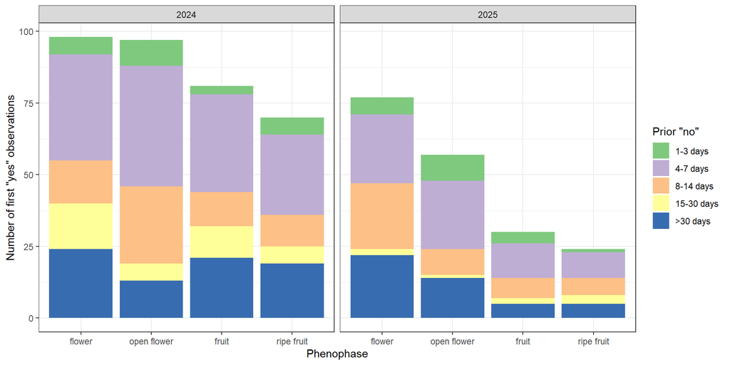

Figure 5: Proportion of first “yes” observations that were associated with a prior “no” with a given number of days, grouped by species. We excluded species with fewer than 10 “yes” observations in both water years. 2024 = November 2023 - September 2024. 2025 = November 2024 - present.

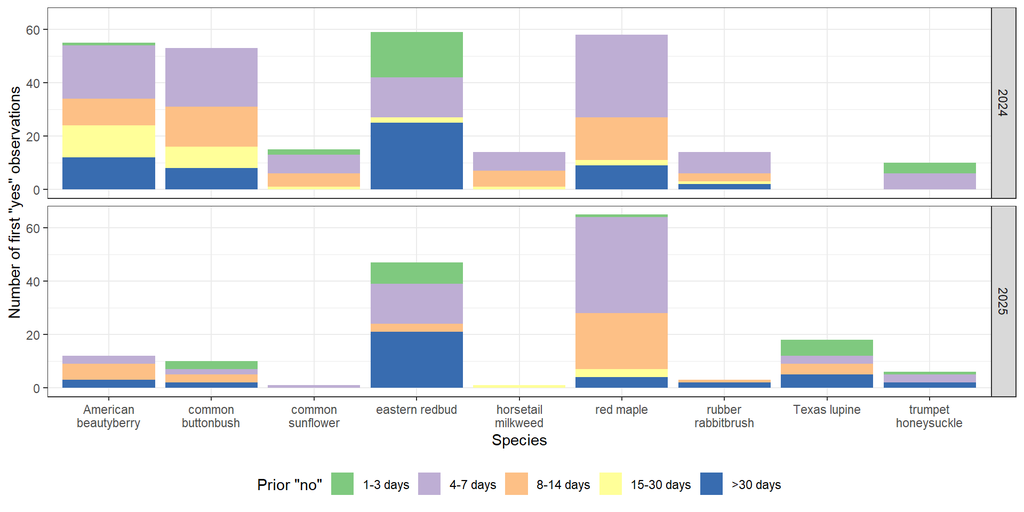

### Plant information

We also extracted information that observers provided about individual plants and summarized this information by species.

```r
ids <- unique(status$individual_id)

idsl <- 1:length(ids) - 1
ids_call <- paste0("individual_id[", idsl, "]=", ids, "&", collapse = "")
ids_call <- str_sub(ids_call, end = -2)

url_base <- "https://services.usanpn.org/npn_portal/individuals/getPlantDetails.json?"
url <- paste0(url_base, ids_call)

# Get information about each plant from API
json_data <- read_json(
  path = url,
  simplifyVector = TRUE
)
df <- json_data %>%
  select(-c(comment, plant_image_url, plant_image_upload_date))

# Append information about species to the plant data
status <- status %>%
  left_join(select(nn_spp, species_id, common_name, scientific_name),
            by = c("common_name", "species_id"))
df <- df %>%
  left_join(distinct(status, individual_id, common_name), by = "individual_id")

# Check that all species in status-intensity data appear in plant info df
# status$individual_id[!status$individual_id %in% df$individual_id]
# df$individual_id[!df$individual_id %in% status$individual_id]
# ok

# Remove any duplicates (for some reason there are some [~20])
df <- distinct(df)
# Check that there's only one row per individual
# length(unique(df$individual_id)); length(ids)

# Look at variable structures
# count(df, patch) # 52 yes, rest are blank
# count(df, patch_size) # 45 with value, rest are blank
# count(df, shade_status) # 110 blank
# count(df, wild) # 0 or 1 or blank (110)
# count(df, watered) # 0 or 1 or blank (112)
# count(df, fertilized) # 0 or 1 or blank (123)
# count(df, gender) # Female (1) or Both (36) or blank (247)
# count(df, planting_date) # 225 blank or "--", rest with mix of year or exact date
# count(df, death_date_observed) # Only 1 value
# count(df, last_date_observed_alive) # Only 1 value
# count(df, death_reason) # 2 Unknown, rest blank

# Summarize by species
spp <- df %>%
  group_by(common_name) %>%
  summarize(n_plants = n(),
            patch_yes = sum(patch == 1),
            patch_with_size = sum(patch_size != ""),
            shade_reported = sum(shade_status != ""),
            wild_yes = sum(wild == 1),
            wild_no = sum(wild == 0),
            wild_unk = sum(wild == ""),
            water_yes = sum(watered == 1),
            water_no = sum(watered == 0),
            water_unk = sum(watered == ""),
            fert_yes = sum(fertilized == 1),
            fert_no = sum(fertilized == 0),
            fert_unk = sum(fertilized == ""),
            gender_f = sum(gender == "Female"),
            gender_b = sum(gender == "Both"),
            gender_unk = sum(gender == ""),
            planting_date = sum(planting_date %in% c("", "--")),
            death_date = sum(death_date_observed != "")) %>%
  data.frame()


allplants <- data.frame(
  common_name = "All plants",
  n_plants = nrow(df),
  patch_yes = sum(df$patch == 1),
  patch_with_size = sum(df$patch_size != ""),
  shade_reported = sum(df$shade_status != ""),
  wild_yes = sum(df$wild == 1),
  wild_no = sum(df$wild == 0),
  wild_unk = sum(df$wild == ""),
  water_yes = sum(df$watered == 1),
  water_no = sum(df$watered == 0),
  water_unk = sum(df$watered == ""),
  fert_yes = sum(df$fertilized == 1),
  fert_no = sum(df$fertilized == 0),
  fert_unk = sum(df$fertilized == ""),
  gender_f = sum(df$gender == "Female"),
  gender_b = sum(df$gender == "Both"),
  gender_unk = sum(df$gender == ""),
  planting_date = sum(df$planting_date %in% c("", "--")),
  death_date = sum(df$death_date_observed != "")
)

plant_info <- rbind(spp, allplants)

# Extract most useful information
plant_info2 <- plant_info %>%
  select(-c(shade_reported, gender_f, gender_b, gender_unk)) %>%
  mutate(patch = paste0(patch_yes, " (", patch_with_size, ")"),
         wild = paste0(wild_yes, "/", wild_no, "/", wild_unk),
         water = paste0(water_yes, "/", water_no, "/", water_unk),
         fertilized = paste0(fert_yes, "/", fert_no, "/", fert_unk)) %>%
  select(-c(patch_yes, patch_with_size, wild_yes, wild_no, wild_unk,
            water_yes, water_no, water_unk, fert_yes, fert_no, fert_unk))
```

| Species | No. plants | Planting date | Death date | Patch (size) | Wild (Y/N/Unreported) | Watered (Y/N/Unreported) | Fertilized (Y/N/Unreported) |
| --- | --- | --- | --- | --- | --- | --- | --- |
| American beautyberry | 47 | 39 | 0 | 3 (3) | 16/16/15 | 10/19/18 | 2/26/19 |
| American star-thistle | 3 | 3 | 0 | 1 (0) | 1/0/2 | 1/0/2 | 0/1/2 |
| Canada goldenrod | 2 | 2 | 0 | 0 (0) | 1/0/1 | 1/0/1 | 0/1/1 |
| Texas lupine | 14 | 9 | 0 | 7 (5) | 6/5/3 | 3/7/4 | 0/10/4 |
| West Indian shrubverbena | 4 | 2 | 0 | 3 (1) | 1/3/0 | 3/0/1 | 0/3/1 |
| aquatic milkweed | 2 | 2 | 0 | 1 (1) | 0/1/1 | 1/0/1 | 0/1/1 |
| black elderberry | 1 | 1 | 0 | 0 (0) | 0/0/1 | 0/0/1 | 0/0/1 |
| blackeyed Susan | 3 | 3 | 0 | 0 (0) | 0/0/3 | 0/0/3 | 0/0/3 |
| blue mistflower | 8 | 7 | 0 | 2 (2) | 0/2/6 | 2/0/6 | 1/1/6 |
| broadleaf milkweed | 2 | 2 | 0 | 2 (2) | 2/0/0 | 0/2/0 | 0/2/0 |
| button eryngo | 3 | 2 | 0 | 0 (0) | 0/3/0 | 0/3/0 | 1/2/0 |
| cardinalflower | 1 | 1 | 0 | 0 (0) | 0/1/0 | 1/0/0 | 0/1/0 |
| common buttonbush | 24 | 22 | 0 | 0 (0) | 6/10/8 | 3/12/9 | 0/14/10 |
| common sunflower | 8 | 7 | 0 | 5 (4) | 3/2/3 | 2/4/2 | 0/4/4 |
| eastern baccharis | 7 | 6 | 0 | 0 (0) | 3/0/4 | 0/3/4 | 0/3/4 |
| eastern purple coneflower | 6 | 5 | 0 | 0 (0) | 0/3/3 | 3/0/3 | 0/3/3 |
| eastern redbud | 38 | 26 | 0 | 0 (0) | 9/16/13 | 11/18/9 | 2/25/11 |
| firewheel | 6 | 5 | 0 | 1 (1) | 0/3/3 | 3/0/3 | 1/2/3 |
| golden crownbeard | 1 | 1 | 0 | 0 (0) | 0/0/1 | 0/0/1 | 0/0/1 |
| green antelopehorn | 4 | 3 | 0 | 1 (1) | 1/2/1 | 2/1/1 | 0/3/1 |
| horsetail milkweed | 3 | 3 | 0 | 2 (2) | 3/0/0 | 0/3/0 | 0/3/0 |
| lemon beebalm | 2 | 2 | 0 | 1 (1) | 1/0/1 | 0/1/1 | 0/1/1 |
| mealycup sage | 7 | 3 | 0 | 3 (3) | 0/6/1 | 5/1/1 | 1/5/1 |
| palmleaf thoroughwort | 2 | 2 | 0 | 1 (1) | 0/2/0 | 2/0/0 | 0/2/0 |
| purple passionflower | 6 | 3 | 0 | 2 (2) | 0/3/3 | 2/2/2 | 0/4/2 |
| purple prairie clover | 5 | 5 | 0 | 0 (0) | 0/0/5 | 0/0/5 | 0/0/5 |
| red maple | 26 | 20 | 1 | 0 (0) | 7/6/13 | 4/10/12 | 0/14/12 |
| rubber rabbitbrush | 5 | 4 | 0 | 1 (1) | 3/1/1 | 0/4/1 | 1/2/2 |
| seaside goldenrod | 1 | 1 | 0 | 1 (1) | 0/1/0 | 1/0/0 | 0/1/0 |
| showy milkweed | 4 | 3 | 0 | 2 (2) | 2/2/0 | 2/2/0 | 0/3/1 |
| spider milkweed | 3 | 3 | 0 | 1 (1) | 1/0/2 | 0/1/2 | 0/1/2 |
| straggler daisy | 1 | 1 | 0 | 0 (0) | 0/0/1 | 0/0/1 | 0/0/1 |
| tall blazing star | 1 | 1 | 0 | 0 (0) | 0/1/0 | 1/0/0 | 0/1/0 |
| trumpet honeysuckle | 1 | 0 | 0 | 0 (0) | 0/1/0 | 1/0/0 | 0/0/1 |
| turkey tangle fogfruit | 6 | 6 | 0 | 2 (2) | 1/1/4 | 1/1/4 | 0/2/4 |
| upright prairie coneflower | 1 | 1 | 0 | 0 (0) | 0/0/1 | 0/0/1 | 0/0/1 |
| wax mallow | 9 | 6 | 0 | 4 (4) | 0/3/6 | 3/2/4 | 1/4/4 |
| white crownbeard | 10 | 8 | 0 | 5 (4) | 6/2/2 | 2/5/3 | 0/7/3 |
| wild bergamot | 7 | 5 | 0 | 4 (4) | 2/4/1 | 4/2/1 | 0/5/2 |
| All plants | 284 | 225 | 1 | 55 (48) | 75/100/109 | 74/103/107 | 10/157/117 |